# Cleveland Baseball Game Duration

Data Exploration

Michael Foley

2023-04-14

This project investigates the increase in game duration and the effect of recent efforts to quicken the pace. Games today last nearly twice as long as they did in 1901. Baseball-Reference has a rich source of game features that might help explain trends in game time. The Baseball-Reference section for the [Cleveland Guardians](https://www.baseball-reference.com/teams/CLE/2023.shtml) lists game-by-game results since their first season in 1901. In [step 01](https://github.com/mpfoley73/cleveland-mlb-games/blob/main/01_get_games.R) of this project I aggregated 123 seasons of data sets, including YTD for 2023, into data frame `cle_games`. `cle_games` is a 19,002 x 23 data frame with one row per game. I also downloaded player season summaries of hitting and pitching statistics. `cle_batting` is a 4,804 x 28 data frame and `cle_pitching` is a 2,142 x 34 data frame each with one row per season and player. This step explores the data sets.

## The Data Sets

For `cle_games`, columns `game_date` and `game_duration` are obviously going to be important. A few others may be useful too: `day_ind` (day or night game), which game of a `doubleheader_game` if applicable, `runs_scored` and `runs_allowed`, `innings`, and `attendance`. The seven character fields are interesting to read for nostalgia’s sake (e.g., Lenny Barker’s [1981](https://www.baseball-reference.com/teams/CLE/1981-schedule-scores.shtml) no-hitter on May 15 was against the Blue Jays and the win brought our record to 16-8), but these features won’t play a role in this analysis. The lone date field, `game_date`, might be useful in the trend analysis, but the emphasis will be on seasonal roll-ups. I wonder about `day_ind`. Compared to lazy afternoons, evening games feel electric and I wonder if that translates into shorter games. I also wonder about `doubleheader_game`. When I played, I felt like two hours of baking in the sun was plenty, but did I do anything to hasten along a doubleheader?

Data summary

| Name | cle_games |
| --- | --- |
| Number of rows | 19002 |
| Number of columns | 23 |
| _______________________ |  |
| Column type frequency: |  |
| character | 7 |
| Date | 1 |
| factor | 4 |
| numeric | 10 |
| Timespan | 1 |
| ________________________ |  |
| Group variables | None |

**Variable type: character**

| skim_variable | n_missing | complete_rate | min | max | empty | n_unique | whitespace |
| --- | --- | --- | --- | --- | --- | --- | --- |
| team | 0 | 1 | 3 | 3 | 0 | 1 | 0 |
| opponent | 0 | 1 | 3 | 3 | 0 | 42 | 0 |
| record | 0 | 1 | 3 | 6 | 0 | 4156 | 0 |
| winning_pitcher | 0 | 1 | 0 | 13 | 92 | 2051 | 0 |
| losing_pitcher | 0 | 1 | 0 | 13 | 92 | 2320 | 0 |
| save | 0 | 1 | 0 | 13 | 13009 | 1047 | 0 |
| orig_sched | 0 | 1 | 0 | 63 | 17528 | 1294 | 0 |

**Variable type: Date**

| skim_variable | n_missing | complete_rate | min | max | median | n_unique |
| --- | --- | --- | --- | --- | --- | --- |
| game_date | 0 | 1 | 1901-04-24 | 2023-04-12 | 1962-09-10 | 17192 |

**Variable type: factor**

| skim_variable | n_missing | complete_rate | ordered | n_unique | top_counts |
| --- | --- | --- | --- | --- | --- |
| day_ind | 0 | 1 | FALSE | 2 | Day: 11703, Nig: 7299 |
| doubleheader_game | 0 | 1 | FALSE | 3 | 0: 15382, 1: 1810, 2: 1810 |
| home_ind | 0 | 1 | FALSE | 2 | Hom: 9512, Awa: 9490 |
| outcome | 0 | 1 | FALSE | 3 | W: 9691, L: 9220, T: 91 |

**Variable type: numeric**

| skim_variable | n_missing | complete_rate | mean | sd | p0 | p25 | p50 | p75 | p100 | hist |
| --- | --- | --- | --- | --- | --- | --- | --- | --- | --- | --- |
| season | 0 | 1.00 | 1961.96 | 35.05 | 1901 | 1932.00 | 1962.0 | 1992.00 | 2023.00 | ▇▇▇▇▇ |
| game_no | 0 | 1.00 | 78.75 | 45.56 | 1 | 39.00 | 78.0 | 118.00 | 164.00 | ▇▇▇▇▆ |
| rank | 0 | 1.00 | 3.69 | 1.97 | 1 | 2.00 | 4.0 | 5.00 | 10.00 | ▇▇▆▂▁ |
| games_back | 0 | 1.00 | 8.03 | 9.39 | -29 | 1.50 | 6.5 | 13.50 | 49.00 | ▁▃▇▂▁ |
| streak | 0 | 1.00 | 0.15 | 2.61 | -12 | -1.00 | 1.0 | 2.00 | 22.00 | ▁▇▃▁▁ |
| runs_scored | 0 | 1.00 | 4.53 | 3.22 | 0 | 2.00 | 4.0 | 6.00 | 27.00 | ▇▃▁▁▁ |
| runs_allowed | 0 | 1.00 | 4.41 | 3.16 | 0 | 2.00 | 4.0 | 6.00 | 24.00 | ▇▅▁▁▁ |
| innings | 0 | 1.00 | 9.18 | 0.90 | 5 | 9.00 | 9.0 | 9.00 | 22.00 | ▁▇▁▁▁ |
| attendance | 4157 | 0.78 | 18285.95 | 13683.34 | 37 | 7049.00 | 15000.0 | 26745.00 | 84587.00 | ▇▅▂▁▁ |
| cli | 450 | 0.98 | 1.61 | 2.26 | 0 | 0.03 | 1.0 | 2.31 | 83.33 | ▇▁▁▁▁ |

**Variable type: Timespan**

| skim_variable | n_missing | complete_rate | min | max | median | n_unique |
| --- | --- | --- | --- | --- | --- | --- |
| game_duration | 856 | 0.95 | 0 | 0 | 0 | 1 |

For `cle_batting`, I will be interested in how the 2023 rule change that increased the base size affected stolen bases, `SB` and `CS`. And did the restrictions on the shift increase batting average, `BA`, and reduce the incentive to hit home runs, `BA`?

Data summary

| Name | cle_batting |
| --- | --- |
| Number of rows | 4804 |
| Number of columns | 28 |
| _______________________ |  |
| Column type frequency: |  |
| character | 2 |
| numeric | 26 |
| ________________________ |  |
| Group variables | None |

**Variable type: character**

| skim_variable | n_missing | complete_rate | min | max | empty | n_unique | whitespace |
| --- | --- | --- | --- | --- | --- | --- | --- |
| Pos | 0 | 1 | 0 | 2 | 56 | 16 | 0 |
| Name | 0 | 1 | 7 | 24 | 0 | 1960 | 0 |

**Variable type: numeric**

| skim_variable | n_missing | complete_rate | mean | sd | p0 | p25 | p50 | p75 | p100 | hist |
| --- | --- | --- | --- | --- | --- | --- | --- | --- | --- | --- |
| season | 0 | 1.00 | 1966.11 | 35.65 | 1901 | 1935.00 | 1968.00 | 1998.00 | 2023 | ▆▆▆▆▇ |
| Age | 0 | 1.00 | 27.56 | 4.22 | 17 | 25.00 | 27.00 | 30.00 | 48 | ▂▇▃▁▁ |
| G | 0 | 1.00 | 44.00 | 49.71 | 0 | 3.00 | 24.00 | 74.00 | 163 | ▇▂▁▁▂ |
| PA | 0 | 1.00 | 151.87 | 208.06 | 0 | 2.00 | 44.00 | 240.25 | 751 | ▇▁▁▁▁ |
| AB | 14 | 1.00 | 135.27 | 184.12 | 0 | 2.00 | 40.00 | 217.00 | 663 | ▇▁▁▁▁ |
| R | 14 | 1.00 | 17.96 | 27.83 | 0 | 0.00 | 3.00 | 26.00 | 140 | ▇▁▁▁▁ |
| H | 14 | 1.00 | 35.86 | 52.75 | 0 | 0.00 | 7.00 | 54.00 | 233 | ▇▁▁▁▁ |
| 2B | 14 | 1.00 | 6.38 | 10.21 | 0 | 0.00 | 1.00 | 9.00 | 64 | ▇▁▁▁▁ |
| 3B | 14 | 1.00 | 1.14 | 2.46 | 0 | 0.00 | 0.00 | 1.00 | 26 | ▇▁▁▁▁ |
| HR | 14 | 1.00 | 2.83 | 6.37 | 0 | 0.00 | 0.00 | 2.00 | 52 | ▇▁▁▁▁ |
| RBI | 14 | 1.00 | 16.59 | 26.45 | 0 | 0.00 | 3.00 | 23.00 | 165 | ▇▁▁▁▁ |
| SB | 14 | 1.00 | 2.42 | 6.11 | 0 | 0.00 | 0.00 | 2.00 | 75 | ▇▁▁▁▁ |
| CS | 535 | 0.89 | 1.26 | 2.71 | 0 | 0.00 | 0.00 | 1.00 | 27 | ▇▁▁▁▁ |
| BB | 14 | 1.00 | 12.86 | 20.96 | 0 | 0.00 | 2.00 | 17.00 | 127 | ▇▁▁▁▁ |
| SO | 14 | 1.00 | 19.21 | 27.39 | 0 | 0.00 | 7.00 | 27.00 | 194 | ▇▁▁▁▁ |
| BA | 1044 | 0.78 | 0.22 | 0.12 | 0 | 0.16 | 0.23 | 0.28 | 1 | ▅▇▁▁▁ |
| OBP | 1037 | 0.78 | 0.28 | 0.14 | 0 | 0.22 | 0.30 | 0.35 | 1 | ▂▇▁▁▁ |
| SLG | 1044 | 0.78 | 0.31 | 0.19 | 0 | 0.20 | 0.32 | 0.41 | 4 | ▇▁▁▁▁ |
| OPS | 1044 | 0.78 | 0.58 | 0.31 | 0 | 0.43 | 0.63 | 0.75 | 5 | ▇▁▁▁▁ |
| OPS+ | 1044 | 0.78 | 59.83 | 82.47 | -100 | 21.00 | 73.00 | 105.00 | 1201 | ▇▁▁▁▁ |
| TB | 14 | 1.00 | 53.02 | 80.59 | 0 | 0.00 | 10.00 | 78.00 | 405 | ▇▁▁▁▁ |
| GDP | 1308 | 0.73 | 2.94 | 4.71 | 0 | 0.00 | 0.00 | 4.00 | 28 | ▇▂▁▁▁ |
| HBP | 14 | 1.00 | 0.98 | 2.10 | 0 | 0.00 | 0.00 | 1.00 | 25 | ▇▁▁▁▁ |
| SH | 14 | 1.00 | 2.39 | 4.94 | 0 | 0.00 | 0.00 | 3.00 | 67 | ▇▁▁▁▁ |
| SF | 1845 | 0.62 | 1.10 | 2.02 | 0 | 0.00 | 0.00 | 1.00 | 16 | ▇▁▁▁▁ |
| IBB | 813 | 0.83 | 0.89 | 2.18 | 0 | 0.00 | 0.00 | 1.00 | 23 | ▇▁▁▁▁ |

I don’t anticipate using `cle_pitching` since everything related to game duration and the effects of rules on pace of game are already captured in the batting statistics. Here is the data set anyway.

Data summary

| Name | cle_pitching |
| --- | --- |
| Number of rows | 2142 |
| Number of columns | 34 |
| _______________________ |  |
| Column type frequency: |  |
| character | 3 |
| numeric | 31 |
| ________________________ |  |
| Group variables | None |

**Variable type: character**

| skim_variable | n_missing | complete_rate | min | max | empty | n_unique | whitespace |
| --- | --- | --- | --- | --- | --- | --- | --- |
| Pos | 0 | 1 | 0 | 2 | 979 | 4 | 0 |
| Name | 0 | 1 | 7 | 24 | 0 | 930 | 0 |
| SO/W | 0 | 1 | 0 | 5 | 70 | 386 | 0 |

**Variable type: numeric**

| skim_variable | n_missing | complete_rate | mean | sd | p0 | p25 | p50 | p75 | p100 | hist |
| --- | --- | --- | --- | --- | --- | --- | --- | --- | --- | --- |
| season | 0 | 1.00 | 1969.81 | 35.83 | 1901.00 | 1940.00 | 1974.00 | 2002.00 | 2023.00 | ▅▅▅▆▇ |
| Age | 0 | 1.00 | 27.52 | 4.24 | 17.00 | 25.00 | 27.00 | 30.00 | 48.00 | ▂▇▃▁▁ |
| W | 0 | 1.00 | 4.52 | 5.61 | 0.00 | 0.00 | 2.00 | 7.00 | 31.00 | ▇▂▁▁▁ |
| L | 0 | 1.00 | 4.30 | 4.45 | 0.00 | 1.00 | 3.00 | 7.00 | 22.00 | ▇▂▂▁▁ |
| W-L% | 373 | 0.83 | 0.46 | 0.27 | 0.00 | 0.33 | 0.50 | 0.61 | 1.00 | ▃▅▇▃▂ |
| ERA | 6 | 1.00 | Inf | NaN | 0.00 | 3.10 | 4.17 | 5.40 | Inf | ▇▁▁▁▁ |
| G | 0 | 1.00 | 22.37 | 17.52 | 0.00 | 7.00 | 20.00 | 34.00 | 81.00 | ▇▅▃▁▁ |
| GS | 0 | 1.00 | 8.87 | 11.49 | 0.00 | 0.00 | 3.00 | 16.00 | 44.00 | ▇▂▁▂▁ |
| GF | 0 | 1.00 | 6.03 | 9.09 | 0.00 | 1.00 | 3.00 | 8.00 | 67.00 | ▇▁▁▁▁ |
| CG | 0 | 1.00 | 2.84 | 5.82 | 0.00 | 0.00 | 0.00 | 2.00 | 36.00 | ▇▁▁▁▁ |
| SHO | 0 | 1.00 | 0.46 | 1.14 | 0.00 | 0.00 | 0.00 | 0.00 | 10.00 | ▇▁▁▁▁ |
| SV | 0 | 1.00 | 1.39 | 4.43 | 0.00 | 0.00 | 0.00 | 1.00 | 46.00 | ▇▁▁▁▁ |
| IP | 0 | 1.00 | 79.03 | 79.38 | 0.00 | 14.20 | 52.15 | 123.07 | 371.10 | ▇▂▂▁▁ |
| H | 0 | 1.00 | 78.81 | 76.61 | 0.00 | 16.00 | 53.00 | 126.00 | 378.00 | ▇▂▂▁▁ |
| R | 0 | 1.00 | 39.13 | 36.14 | 0.00 | 9.00 | 27.00 | 62.00 | 167.00 | ▇▃▂▁▁ |
| ER | 0 | 1.00 | 33.77 | 31.13 | 0.00 | 8.00 | 23.00 | 53.75 | 150.00 | ▇▃▂▁▁ |
| HR | 0 | 1.00 | 5.98 | 6.81 | 0.00 | 1.00 | 3.00 | 9.00 | 37.00 | ▇▂▁▁▁ |
| BB | 0 | 1.00 | 29.42 | 28.66 | 0.00 | 7.00 | 21.00 | 44.00 | 208.00 | ▇▂▁▁▁ |
| IBB | 377 | 0.82 | 2.22 | 2.65 | 0.00 | 0.00 | 1.00 | 3.00 | 20.00 | ▇▁▁▁▁ |
| SO | 0 | 1.00 | 44.94 | 49.55 | 0.00 | 8.00 | 29.00 | 64.00 | 348.00 | ▇▂▁▁▁ |
| HBP | 0 | 1.00 | 2.14 | 2.66 | 0.00 | 0.00 | 1.00 | 3.00 | 24.00 | ▇▁▁▁▁ |
| BK | 0 | 1.00 | 0.25 | 0.64 | 0.00 | 0.00 | 0.00 | 0.00 | 8.00 | ▇▁▁▁▁ |
| WP | 0 | 1.00 | 2.21 | 2.72 | 0.00 | 0.00 | 1.00 | 3.00 | 18.00 | ▇▂▁▁▁ |
| BF | 0 | 1.00 | 338.48 | 331.31 | 0.00 | 67.25 | 231.00 | 529.00 | 1548.00 | ▇▂▂▁▁ |
| ERA+ | 71 | 0.97 | 104.32 | 56.38 | 3.00 | 74.00 | 95.00 | 122.00 | 854.00 | ▇▁▁▁▁ |
| FIP | 8 | 1.00 | 4.41 | 2.41 | -2.89 | 3.35 | 4.09 | 4.85 | 60.13 | ▇▁▁▁▁ |
| WHIP | 8 | 1.00 | 1.57 | 0.70 | 0.00 | 1.27 | 1.43 | 1.67 | 15.00 | ▇▁▁▁▁ |
| H9 | 8 | 1.00 | 9.90 | 4.32 | 0.00 | 8.00 | 9.20 | 10.80 | 54.00 | ▇▂▁▁▁ |
| HR9 | 8 | 1.00 | 0.87 | 1.24 | 0.00 | 0.20 | 0.70 | 1.10 | 27.00 | ▇▁▁▁▁ |
| BB9 | 8 | 1.00 | 4.19 | 3.31 | 0.00 | 2.70 | 3.60 | 4.88 | 81.00 | ▇▁▁▁▁ |
| SO9 | 8 | 1.00 | 5.32 | 3.00 | 0.00 | 3.30 | 4.80 | 7.00 | 27.00 | ▇▅▁▁▁ |

### Tsibbles

I will use the **tsibble** package for time series analysis. To get an accurate measure of pace of play, I will standardize variables to per-nine-innings.

```r
# Batting and pitching are at the player/season granularity. Summarize to
# team/season.
cle_batting_season <- cle_batting %>%
  mutate(`1B` = H - (`2B` + `3B` + HR)) %>%
  rename(yr = season) %>%
  summarize(
    .by = yr,
    Age = weighted.mean(Age, G),
    across(c(PA:SO, TB:`1B`), ~sum(.x, na.rm = TRUE))
  ) %>%
  mutate(
    BA = H / AB,
    OBP = (H + BB + HBP) / (AB + BB + HBP + SF),
    SLG = (`1B` + 2*`2B` + 3*`3B` + 4*HR) / AB,
    OPS = OBP + SLG
  ) %>%
  rename_with(~ paste0("batting_", .x), c(Age:OPS))

cle_pitching_season <- cle_pitching %>%
  rename(yr = season) %>%
  summarize(
    .by = yr,
    Age = weighted.mean(Age, G),
    across(c(CG:BF), ~sum(.x, na.rm = TRUE))
  ) %>%
  mutate(
    ERA = 9 * ER / IP,
    WHIP = (BB + H) / IP,
    H9 = 9 * H / IP,
    HR9 = 9 * HR / IP,
    BB9 = 9 * BB / IP,
    SO9 = 9 * SO / IP,
    `SO_per_BB` = SO / BB
  ) %>%
  select(-c(IP)) %>%
  rename_with(~ paste0("pitching_", .x), c(Age:SO_per_BB))

# Standardize games to a 9-inning game
cle_games_per9 <- cle_games %>%
  mutate(
    game_hrs = as.duration(game_duration) / dhours(1),
    game_hrs9 = game_hrs / innings * 9,
    runs = runs_scored + runs_allowed,
    runs9 = runs / innings * 9
  )

# Create a time-series tibble (tsibble).
cle_batting_tsibble_yr <- tsibble(cle_batting_season, index = yr)
cle_pitching_tsibble_yr <- tsibble(cle_pitching_season, index = yr)

# key includes doubleheader game in order to index by game.
cle_tsibble <- tsibble(cle_games_per9, key = c(doubleheader_game), index = game_date)

# Summarize annual, monthly
summarize_games <- function(dat) {
  dat %>% summarize(
    game_hrs9 = mean(game_hrs9, na.rm = TRUE),
    home_att = mean(if_else(home_ind == "Home", attendance, NA_real_), na.rm = TRUE),
    wins = sum(str_sub(outcome, 1, 1) == "W"),
    losses = sum(str_sub(outcome, 1, 1) == "L"),
    runs9 = mean(runs9)
  )
}
# Annual summary
cle_tsibble_yr <- cle_tsibble %>%
  index_by(yr = ~ year(.)) %>%
  summarize_games() %>%
  inner_join(cle_batting_tsibble_yr, join_by(yr)) %>%
  inner_join(cle_pitching_tsibble_yr, join_by(yr)) %>%
  mutate(
    winning_pct = wins / (wins + losses)
  )

# Monthly summary. Not sure how best to deal with missing values (Nov - Mar).
cle_tsibble_yrmo <- cle_tsibble %>%
  index_by(yrmo = ~ yearmonth(.)) %>%
  summarize_games()

cle_tsibble_mmm <- cle_tsibble %>%
  index_by(mmm = ~ month(.)) %>%
  summarize_games() %>%
  mutate(mmm = ym(paste0("9999-", mmm)))
```

# Feature Exploration

Most features are fully populated. The `attendance` data is somewhat spotty, primarily in the early years (and also in double-header games because attendance is only recorded for one game of a doubleheader). `game_duration` is also spotty in the early years.

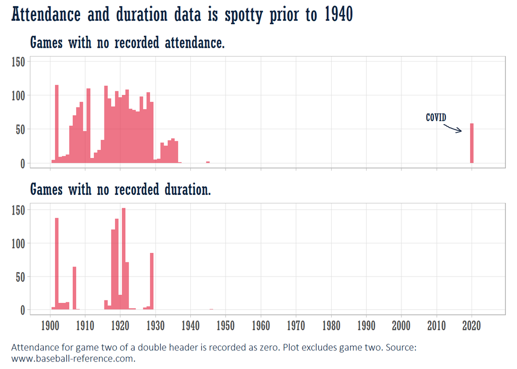

Curious about the attendance data. Do the peaks and troughs correlate with the team’s success? The answer is usually “yes”, except for 1954. The Tribe won 111 games that year, but drew only around 20,000 per game, a 50% drop from their 1948 pennant-winning season. In a way, it was the 1948-49 seasons that were anomalous. The Tribe had never seen crowds like that before, and wouldn’t again until 1995.

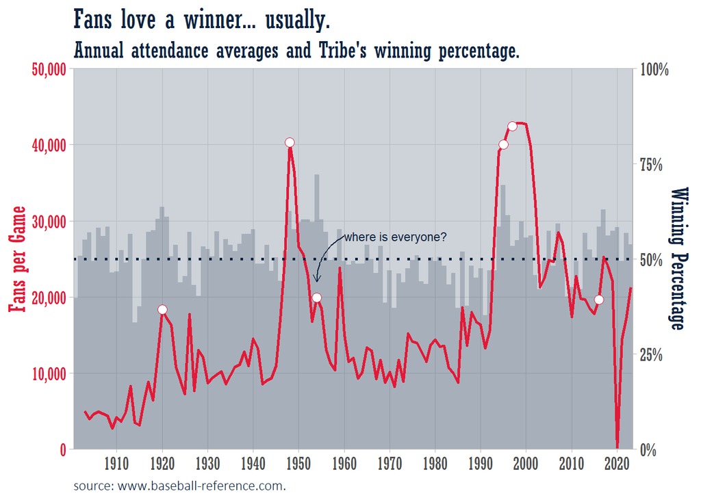

As an aside, check out 1917 and 1918. Game attendance does not seem unusual those two years despite WWI and the influenza pandemic. The US entered WWI in Apr ’17 and the war ended after the season concluded in ’18. The 1918 influenza pandemic started in the spring, but seems to have really taken off around October. Baseball survived the war as an acceptable diversion from civic duty, and in fact patriotic elements were integrated into the games.

Doubleheaders were common through the mid-1960s. Let’s take a closer look. Over 50% of baseball games in 1943 were played as part of a doubleheader. Doubleheaders have been relatively rare since the 1980s.

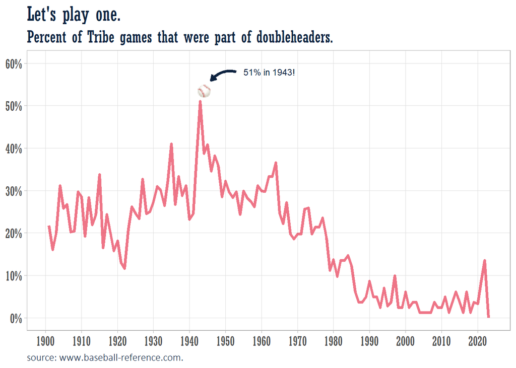

As with the attendance data, game duration data is also frequently unavailable prior to 1930.

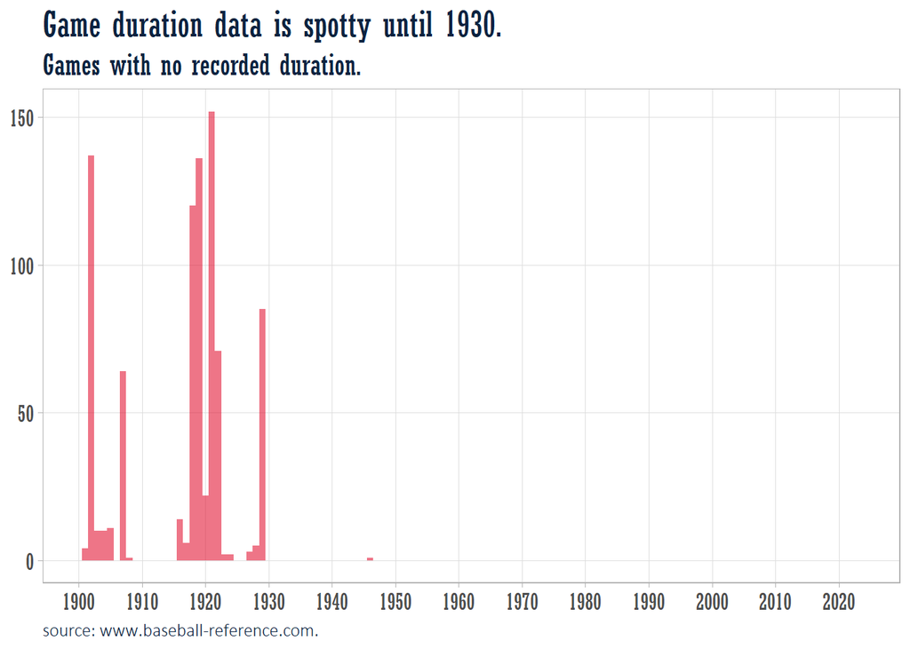

## Game Duration

If it seems like Tribe games are taking longer to complete, you are right. The annual average game duration has been increasing since 2003. Prior to 2003, it had briefly fallen from an all-time high of 3 hours 9 minutes in 2000. Early in the 1900s, games took a little over an hour and a half, but were increasing and by 1920 game times had climbed over two hours. From 1921 to 1945 game times were steady at about two hours, but began to climb again after WWII, reaching two and half hours by 1955. Game times stabilized at 2.5 hours from 1955 to 1975, before rising again. The average Tribe game time in 2021 was 3 hours 5 minutes.

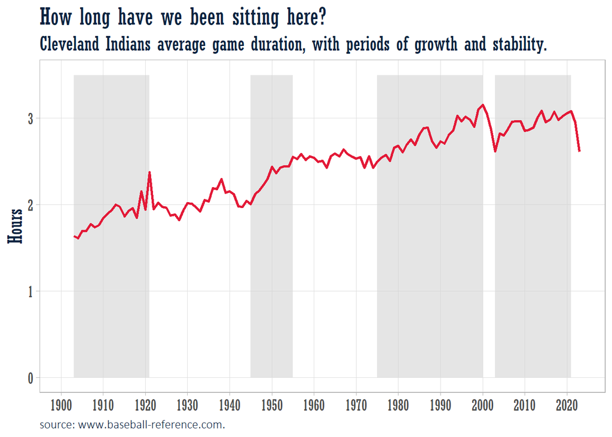

Doubleheaders have become less common while game times have increased. Is there a negative correlation, perhaps a compensating effect? Let’s print the same chart, but control for whether the game is part of a doubleheader. The answer is no, doubleheaders are irrelevant. The average doubleheader game is shorter by all of 2 minutes.

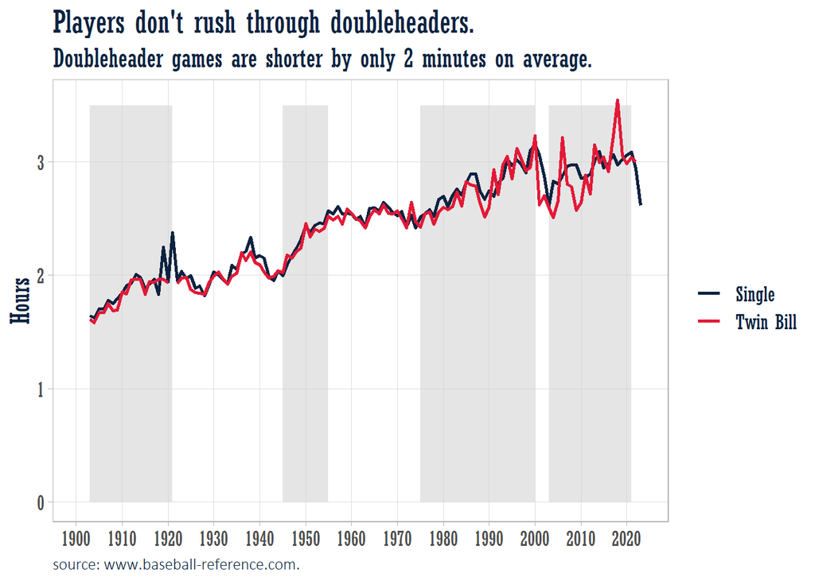

How about day games? Until the late 1930s, all games were played in the afternoon. By the mid 1970s day games were primarily on weekends. While there might be a different dynamic to paying in the afternoon (*it’s hot - let’s get out of here!*), the data doesn’t bear that out. The advent of night games is not associated with longer games.

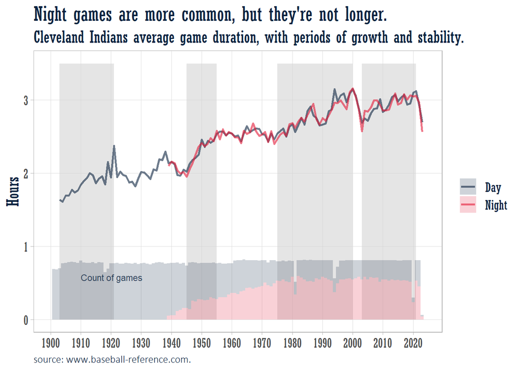

I’m curious about the dip in game duration between 2000 and 2003. Game duration reached its peak at 3:09 per game in 2000. Then it underwent a brief period of decline, falling to 2:37 in 2003. It climbed back to 3:05 in 2021. I wonder if the reduction in offense after the steroid era is related. Below is the trend of average game times with total runs scored. They both plummeted over that three year period, but they’ve been moving in opposite directions since 2010.

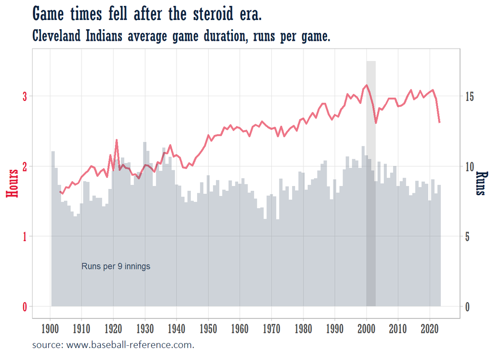

[output not shown]

[output cut: 80 more lines]

Incidentally, compare the offense in the 1930s to the steroid era of the 1990s. And there’s that year of the pitcher, 1968. But then 1972 does not look so hot. It should be noted that these are just Cleveland Indians games. There may be seasons when the Tribe had decent pitching, but no hitting, or vice-versa (or, sadly, neither).

## Duration Trends

Average game duration does not appear to change much within seasons - it looks like it falls about .2 hours (12 minutes) over the course of the season. The apparent increase in March game times is an artifact of March games not occurring until 1998.

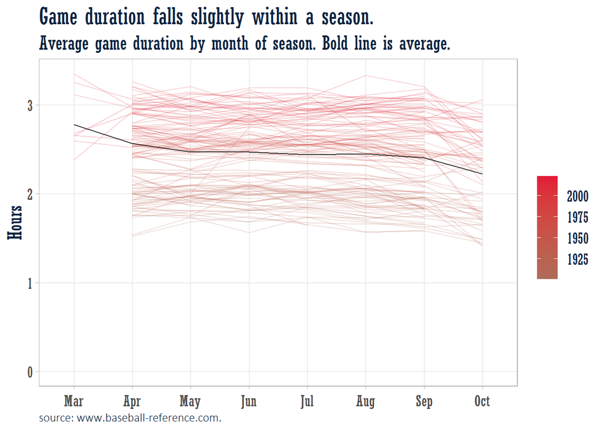

## Benchmark Forecasts

- The **average method** projects the historical average, $\hat{y}_{T+h|T} = \bar{y}.$
- The **naive method** projects the last observation, $\hat{y}_{T+h|T} = y_T.$
- The **seasonal naive method** projects the last seasonal observation, $\hat{y}_{T+h|T} = y_{T+h-m(k+1)}$.

The methods can include drift, a straight line from the first and last observation, $\hat{y}_{T+h|T} = y_T + h\left(\frac{y_T - y_1}{T-1}\right).$

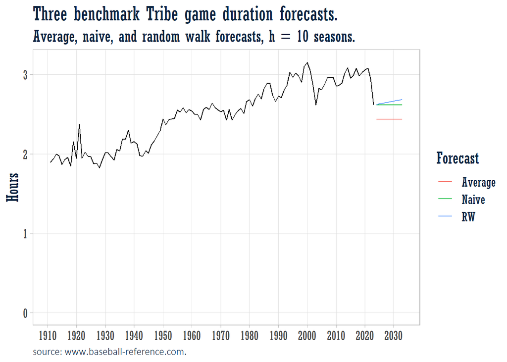